# ggplot2 Tips and Tricks and Extensions

Mike K Smith

25 November, 2019

```r
library(tidyverse)
knitr::opts_chunk$set(message = FALSE, warning = FALSE)
```

## Aims

One of the great strengths of the R developer community is that developers contribute to and extend functionality of existing packages. There is a growing number of extension packages that uses `ggplot2` principles, objects and builds on this, extending and enhancing the functionality of that package.

This document highlights some that I personally find useful. I’m not presenting an exhaustive list, nor ALL of the functionality within each, but rather highlighting particular functions or functionality that illustrates what the package can do for you.

## Resources & background reading

Start with “R for Data Science” section on Data Visualization using `ggplot2`. https://r4ds.had.co.nz/data-visualisation.html

Then I can heartily recommend Claus O. Wilke’s “Fundamentals of Data Visualization”. https://serialmentor.com/dataviz/ This book gives good advice on how you should represent different data types, but also gives some good practice on making your visualizations easier and quicker for others to understand and digest the relevant information.

Finally check out https://www.ggplot2-exts.org/ for a good review of ggplot2 extensions.

# ggplot2 tips and tricks

## Creating `ggplot2` plots for use in examples

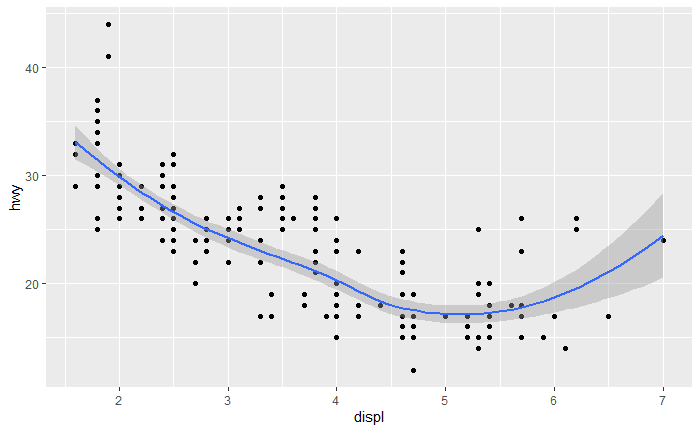

```r
plot1 <- mpg %>%
  ggplot(mapping = aes(x = displ, y = hwy)) +
  geom_point() +
  geom_smooth()

plot1
```

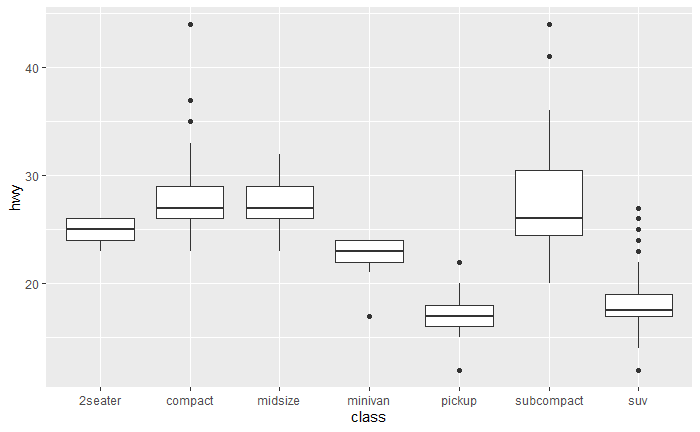

```r
plot3 <- ggplot(data=mpg, mapping=aes(x = class, y = hwy)) +
  geom_boxplot()
plot3
```

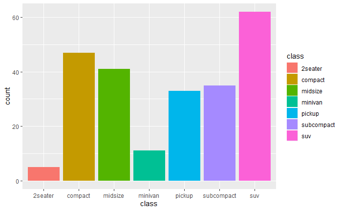

```r
plot4 <- ggplot(mpg) +
  geom_bar(aes(class,fill=class))
plot4
```

### ggplot2 - Add titles, subtitles, captions, axes labels

One of the great things about `ggplot2` is the way that you can create graphs quickly for your own use (to visualize data), but then you can take that object and refine it ready for presentation or publication. Here we add labels and titles to an existing plot.

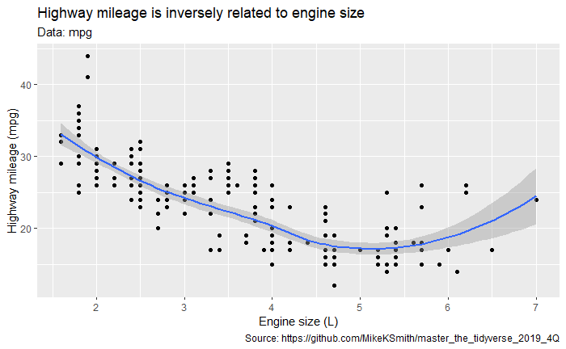

```r
plot1 +
  labs(title = "Highway mileage is inversely related to engine size",
       subtitle = "Data: mpg",
       x = "Engine size (L)",
       y = "Highway mileage (mpg)",
       caption = "Source: https://github.com/MikeKSmith/master_the_tidyverse_2019_4Q")
```

### ggplot2 - Using `%+%` to change the dataset

One often overlooked functionality in `ggplot2` is the ability to change the dataset within the `ggplot2` object and essentially replay the same graph for new data. This functionality is really useful if you have draft data which you can use to create early visualizations which you might want to refine later with the final data. The assumption here is that variable names won’t change, since the `mapping` to `aes`thetics is carried over.

In the case below, we have to slightly change variable names in the `mtcars` dataset to get it to match the `mpg` data. But once we’ve done that we can simply update `plot1` with the new data.

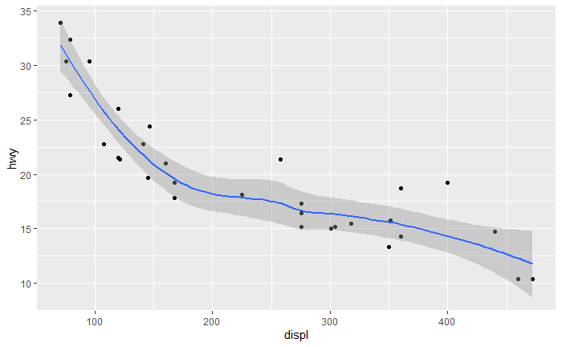

```r
mtcars2 <- mtcars %>%
  rename(hwy = mpg,
         displ = disp)

plot2 <- plot1 %+%
  mtcars2
plot2
```

### Use forcats library functions to sort factors by size of some variable

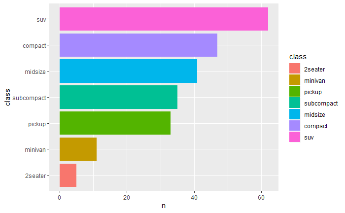

```r
plot5 <- mpg %>%
  group_by(class) %>%
  summarise(n = n()) %>%
  mutate(class = fct_reorder(class, n)) %>%
  ggplot(mapping = aes(x = class,fill=class)) +
  geom_col(mapping = aes(y = n)) +
  coord_flip()
plot5
```

## patchwork - arrange multiple plots

The `patchwork` package (by Thomas Lin Pedersen - https://patchwork.data-imaginist.com/) allows the user to define how to combine graphs. The `+` operator here combines plots into a single plot object. `plot_annotation` then allows us to define overarching titles, labels, annotations. `tag_levels` defines how you might want to identify the graphs and `tag_suffix` pastes onto the end of `tag_level`.

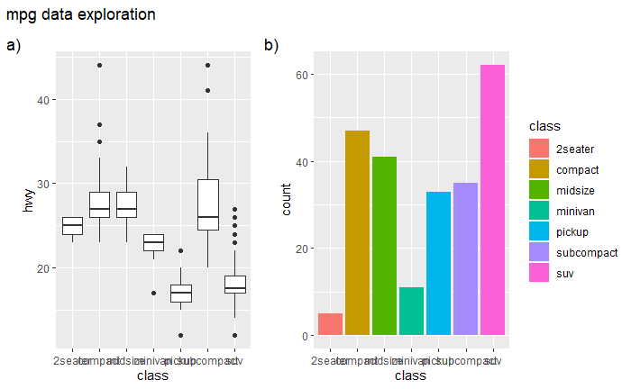

```r
library(patchwork)
plot3 + plot4 + plot_annotation(title = "mpg data exploration",
                                tag_levels="a", tag_suffix = ")")
```

## ggeasy - easy access to theme aspects

The x-axis `class` variable names above look AWFUL when the plots are pulled into `patchwork`. I know that in `ggplot2` I can rotate the axes labels… but can I recall the specific theme settings?

The `ggeasy` package (by Jonathan Carroll - https://jonocarroll.github.io/ggeasy/) provides quick access to tweak commonly used `ggplot2` theme settings.

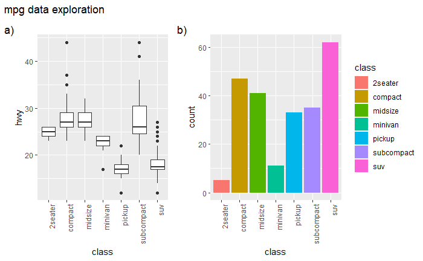

```r
library(ggeasy)
plot3b <- plot3 +
  easy_rotate_x_labels(side = "right")
plot4b <- plot4 +
  easy_rotate_x_labels(side = "right")

plot3b + plot4b + plot_annotation(title = "mpg data exploration",
                                tag_levels="a", tag_suffix = ")")
```

## patchwork continued - Combining many plots

Here we’re using patchwork to produce a slightly more complex layout, combining `plot3` and `plot4` in one row, then `plot1` underneath. The `-` signifies that the combined `plot3 + plot4` are on the same level as `plot1`, and `plot_layout` defines that there is one column.

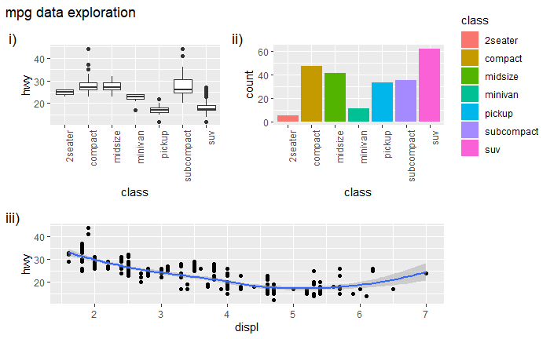

```r
plot3b + plot4b - plot1 + plot_layout(ncol=1) + plot_annotation(title = "mpg data exploration",
                                                              tag_levels="i", tag_suffix = ")")
```

### Use Data Visualization best practice

In the combined graph of `plot3 + plot4` above, there is a lot of repeated information in the graphic (vehicle class, legends etc.). By flipping the plot to be horizontal, we can show the boxplot with the bar chart and eliminate much of the redundant information.

Here we’re also using the `ggeasy` functions `easy_remove_legend()` and `easy_remove_y_axis()` to remove the extraneous information from `plot4c`.

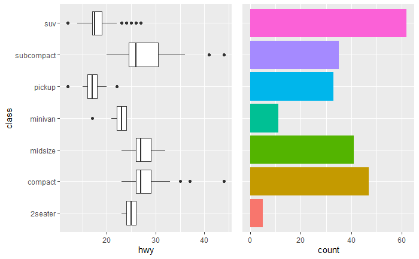

```r
plot3c <- plot3 + coord_flip()
plot4c <- plot4 + coord_flip() +
  easy_remove_legend() +
  easy_remove_y_axis()

plot3c + plot4c
```

## cowplot - templates for publication ready plots

The `cowplot` package (by Claus O. Wilke - https://wilkelab.org/cowplot/index.html) implements many of the standards and recommendations from his “Fundamentals of Data Visualization” book. It extends `ggplot2` with themes for publication, functions for plot alignment and additional annotations.

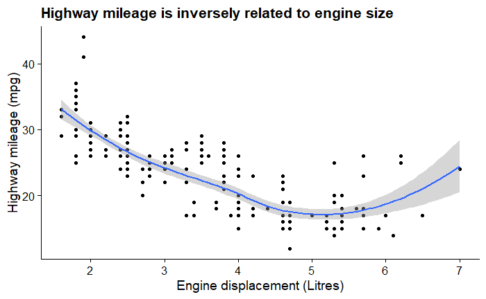

```r
library(cowplot)
plot1 +
  labs(title="Highway mileage is inversely related to engine size",
       x = "Engine displacement (Litres)",
       y = "Highway mileage (mpg)") +
   theme_cowplot(font_size = 14)
```

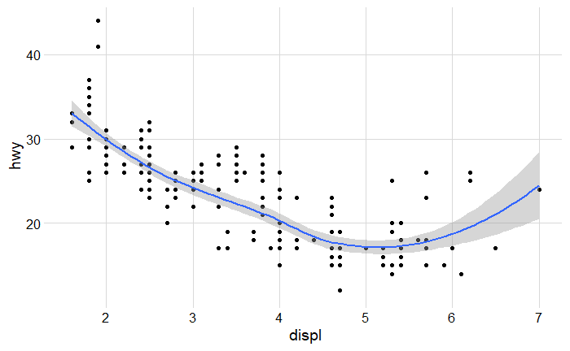

```r
plot1 +
   theme_minimal_grid()
```

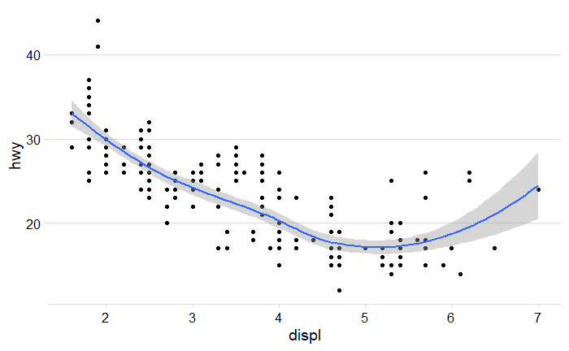

```r
plot1 +
   theme_minimal_hgrid()
```

### Adding annotations and text to plots

The `ggdraw` function with the `cowplot` package takes an existing `ggplot2` object and sets up a drawing layer for additional annotation on top. Here we’re adding a “DRAFT” watermark.

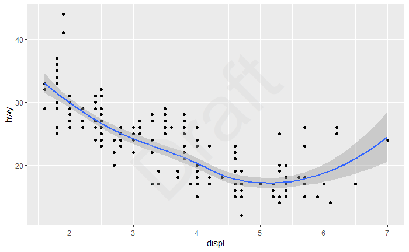

```r
ggdraw(plot1) +
  draw_label("Draft", color = "light grey", alpha=0.3, size = 100, angle = 45)
```

### Using `stamp` to label plots

The `stamp` functionality allows you to label an attribute of a whole graphic. In the book, Wilke labels plots as “ugly” or “bad”, but here we’re marking the whole graph as “DRAFT”. This is perhaps less obtrusive than the watermark above.

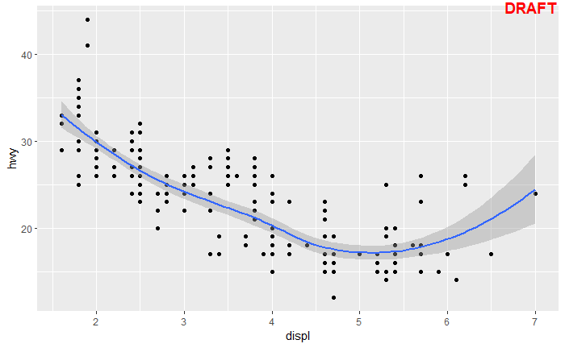

```r
stamp(plot1, label = "DRAFT", color = "red")
```

## ggrepel to label points without overlap

The `ggrepel` package (by Kamil Slowikowsi - https://slowkow.com/ggrepel) has been developed to ensure that text labels in plots do not overlap each other, do not cover data points, nor fall outside of the plotting area. The method of doing so is indistinguishable from magic (or so it seems to me).

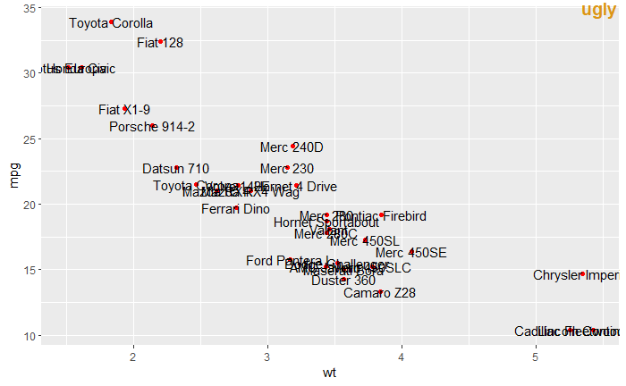

```r
library(ggrepel)

plot_ugly <- ggplot(mtcars) +
  aes(
    x = wt, y = mpg,
    label = rownames(mtcars)
  ) +
  geom_point(color = "red") +
  geom_text()

stamp_ugly(plot_ugly)
```

[figure not shown]

```r
ggplot(mtcars) +
  aes(
    x = wt, y = mpg,
    label = rownames(mtcars)
  ) +
  geom_point(color = "red") +
  geom_text_repel()
```

## gghighlight - highlighting visualization items based on predicates

`gghighlight` (by Hiroaki Yutani - https://yutannihilation.github.io/gghighlight/index.html) is a `ggplot2` extension which highlights `ggplot2` `geoms` that match a given predicate.

In many cases this leads to the recommendations in “Fundamentals of Data Visualization” because is allows the reader to focus straight in on the particular element of the plot that is key to the claims being made. It helps the “story” of our data visualization…

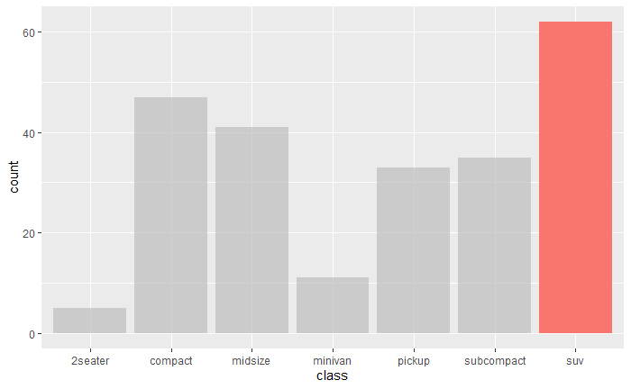

```r
library(gghighlight)

plot4 +
  gghighlight(class == "suv")
```

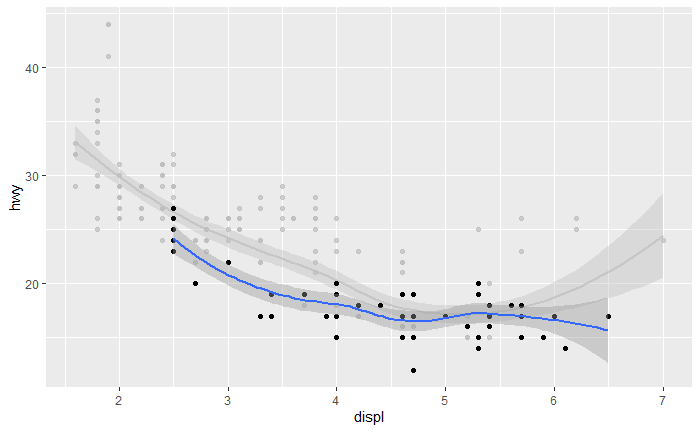

```r
plot1 +
  gghighlight(class == "suv")
```

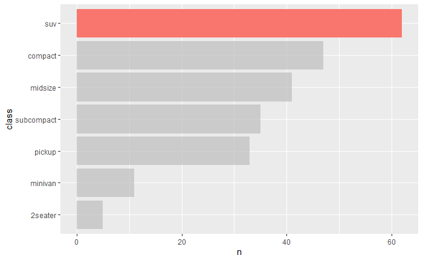

```r
plot5 +
  gghighlight(class == "suv") +
  theme(legend.position="none")
```

## ggridges to compare densities neatly

`ggridges` (by Claus O Wilke - https://cran.r-project.org/web/packages/ggridges/vignettes/introduction.html) is a useful extension for plotting many densities, or other ridgeline visualizations where you may wish to plot the ridges by a categorical variable. `ggridges` stacks these plots so that the individual ridges or densities are easily visible, but compactly.

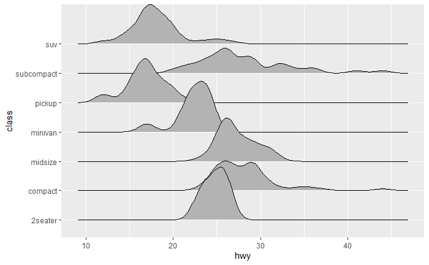

```r
library(ggridges)

ggplot(data = mpg, mapping = aes(x = hwy, y = class)) +
  geom_density_ridges()
```

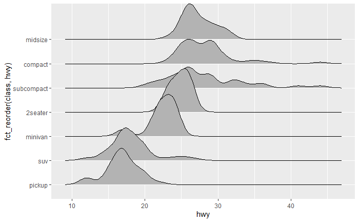

```r
## Using fct_reorder from the `forcats` package to sort the factor
## by the median of `hwy` within each class.
ggplot(data = mpg, mapping = aes(x = hwy, y = fct_reorder(class, hwy))) +
  geom_density_ridges()
```

## GGally - Quick exploratory data analysis

`ggally` (by the GGobi Foundation - https://ggobi.github.io/ggally/) provides useful matrix plots of data and is really well suited to quick data visualization for exploratory data analysis.

`ggscatmat` quickly produces a scatterplot matrix, density and correlation readout for continuous variables.

`ggpairs` is a more complete visualization of both continuous and categorical variables, but is somewhat slower than `ggscatmat`.

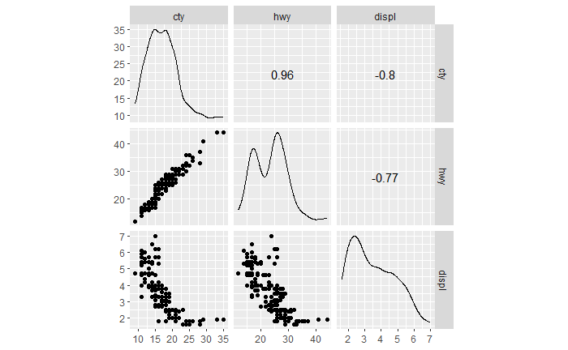

```r
library(GGally)

## Continuous outcomes only can use the quicker `ggscatmat`
mpg %>%
  select(cty, hwy, displ) %>%
  ggscatmat()
```

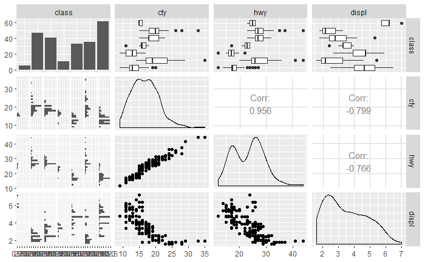

```r
## For more general use with both categorical and continuous variables
## use ggpairs. Although function this is slower.
mpg %>%
  select(class, cty, hwy, displ) %>%
  ggpairs()
```

## ggforce - additional geoms and extensions to ggplot2

`ggforce` (by Thomas Lin Pedersen - https://ggforce.data-imaginist.com/) provides additional `geoms` and extensions to `ggplot2`.

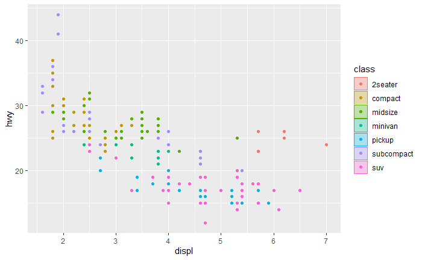

```r
library(ggforce)

plot6 <- mpg %>%
  ggplot(mapping = aes(x = displ, y = hwy, colour = class)) +
  geom_point() +
  geom_mark_ellipse(aes(fill=class))
plot6
```

[figure not shown]

```r
## Alternatively label the overlapping ellipses
plot6 +
  geom_mark_ellipse(aes(label=class))
```

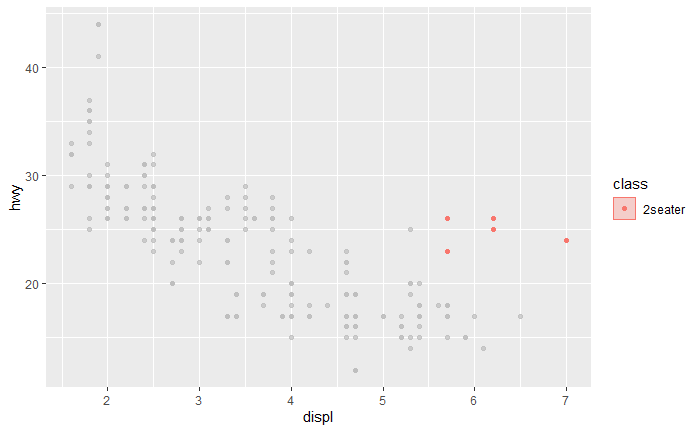

```r
## Perhaps better using gghighlight
plot6 +
  gghighlight(class == "2seater", use_direct_label = FALSE)
```

In addition `ggforce` provides the `facet_zoom` functionality to provide one visualization which shows the overview of the data, but zooms in to a predicate region, or an x- or y-axis region.

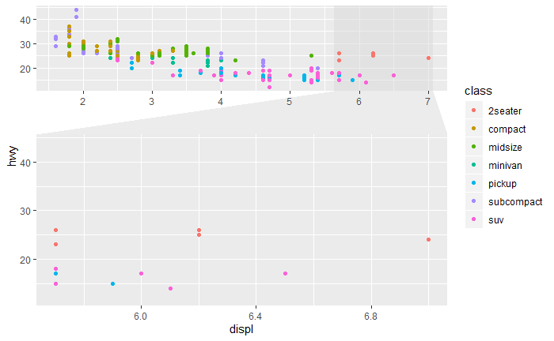

```r
## Zoom in on the 2seater class
ggplot(data = mpg, mapping = aes(x = displ, y = hwy, colour = class)) +
  geom_point() +
  facet_zoom(class=="2seater")
```

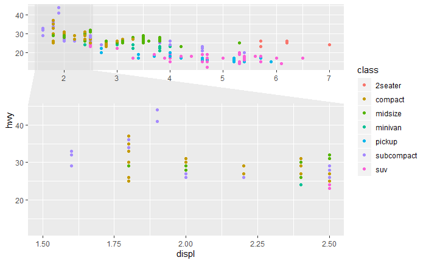

```r
## Alternatively zoom by x-axis limits
ggplot(data = mpg, mapping = aes(x = displ, y = hwy, colour = class)) +
  geom_point() +
  facet_zoom(xlim=c(1.5, 2.5))
```